# A quick guide to deedR

#### b) Get the raw data, transform it and analyze it.

Now let’s play a little bit with the data we collected. We’re going to build a dataframe that gathers all the IDESE information for the city of Gramado in one place.

```r
my_data <-
  ft_table |>
  dplyr::left_join(
    data_muni,
    by = c("geo_id_municipio" = "geo_id",
           "geo_name_municipio" = "geo_name")
  ) |>
  dplyr::rename(value_municipio = value) |>
  dplyr::left_join(
    data_micro,
    by = c("geo_id_micro" = "geo_id",
           "geo_name_micro" = "geo_name",
           "var_id" = "var_id",
           "var_name" = "var_name",
           "year" = "year",
           "um_name" = "um_name",
           "um_acronym" = "um_acronym",
           "note" = "note")
  ) |>
  dplyr::rename(value_micro = value) |>
  dplyr::left_join(
    data_meso,
    by = c("geo_id_meso" = "geo_id",
           "geo_name_meso" = "geo_name",
           "var_id" = "var_id",
           "var_name" = "var_name",
           "year" = "year",
            "um_name" = "um_name",
           "um_acronym" = "um_acronym",
           "note" = "note")
  ) |>
  dplyr::rename(value_meso = value) |>
  dplyr::left_join(
    data_corede,
    by = c("geo_id_corede" = "geo_id",
           "geo_name_corede" = "geo_name",
           "var_id" = "var_id",
           "var_name" = "var_name",
           "year" = "year",
           "um_name" = "um_name",
           "um_acronym" = "um_acronym",
           "note" = "note")
  ) |>
  dplyr::rename(value_corede = value) |>
  dplyr::left_join(
    data_estado,
    by = c("geo_id_estado" = "geo_id",
           "geo_name_estado" = "geo_name",
           "var_id" = "var_id",
           "var_name" = "var_name",
           "year" = "year",
            "um_name" = "um_name",
           "um_acronym" = "um_acronym",
           "note" = "note")
  ) |>
  dplyr::rename(value_estado = value) |>
  dplyr::filter(geo_name_municipio == "Gramado")
```

#### c) Use your preferred plotting package to visualize it

Now, let’s make some diagrams to understand the behaviour of each indicator in time. In our case, we will use ggplot2. Before we start, let’s transform our wide data to long format.

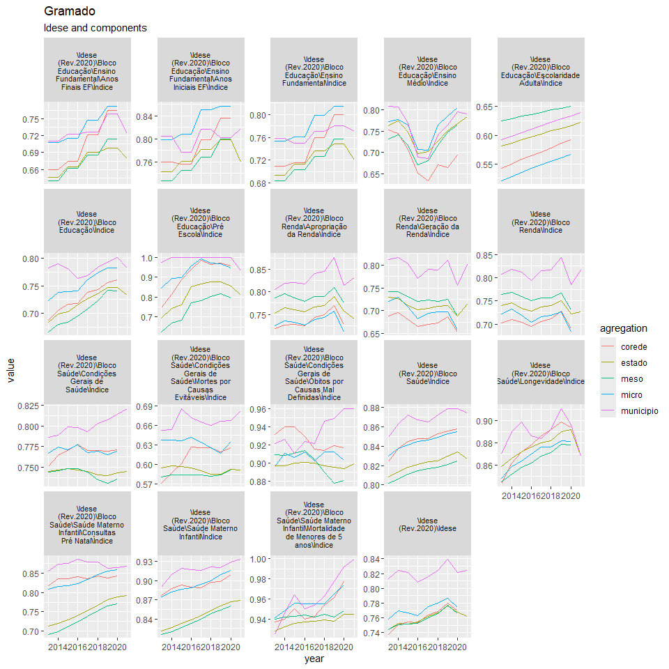

```r
library(ggplot2)
#Transform the data to better fit our ggplot
idese <-
  my_data |>
  dplyr::mutate(year = paste0("01-01-",year) |> lubridate::dmy()) |>
  tidyr::gather(
    key = agregation,
    value = value,
    value_municipio,value_micro,value_meso,value_corede,value_estado
  ) |>
  dplyr::mutate(agregation = stringr::str_remove_all(agregation,"value_"))

#Build the graphs
idese_plot <-
  idese |>
  ggplot2::ggplot(
    ggplot2::aes(x = year,
                 y = value,
                 colour = agregation)
  ) +
  ggplot2::geom_line() +
  ggplot2::facet_wrap(~var_name, scales = "free_y", labeller = ggplot2::label_wrap_gen(width=20)) +
  ggplot2::theme(strip.text = ggplot2::element_text(size=8)) +
  ggplot2::ggtitle(label = "Gramado",
                   subtitle = "Idese and components")

#Plot it!
print(idese_plot)
```

### Example 2: Calculate descriptive statistics on Establishments data from RAIS in each Corede

to be implemented…